# A1 Cyclists and Rain in Auckland

Yifan Luo (骆轶凡)

2020/5/2

## 1. Question 1

According to the definition, tidy data has one row per observation and one column per variable (and one table per type of observation unit).

In this case, we have different forms of `Date` in cycling data and rainfall data. For example, `Sun 1 Jan 2017` (cycling) is represented as `20170101` (rainfall). If we combine these data sets, we have to modify and uniform `Date` column beacause it is the key in joining process.

Moreover, some routes in cycling data sets have different names through the three years. For example, `Curran St total` (2016) is replaced with `Curran Street Total` (2017). Also, updated routes cause inconsistent numbers of variables, there are 32 routes in 2016 but 39 routes in 2017 and 43 routes in 2018.

Unfortunately, we indeed have sereval `NA` ’s in these data sets.

## 2. Question 2

First, let’s import `tidyverse` library and several data sets we need.

```r
library(tidyverse)
cycling_16 <- read.csv("./datasets/dailyakldcyclecountdata2016_updated.csv")  # daily cycling data in 2016
cycling_17 <- read.csv("./datasets/dailyakldcyclecountdata2017_1.csv")  # daily cycling data in 2017
cycling_18 <- read.csv("./datasets/dailyakldcyclecountdata2018.csv")  # daily cycling data in 2018

# We only eliminate needless description from the original txt's
rainfall_16_17 <- read.csv("./datasets/rain2016-17_modified.txt")  # hourly rainfall data in 2016 and 2017
rainfall_18 <- read.csv("./datasets/rain2018_modified.txt")  # hourly rainfall data in 2018
```

### 2.1 Handling Rainfall Data Set

Initially, let’s take a glance of `rainfall_16_17` and `rainfall_18`.

```r
head(rainfall_16_17)
```

```
##   Station Date.NZST. Time.NZST. Amount.mm. Period.Hrs. Freq
## 1   22719   20160101          0          0           1    H
## 2   37852   20160101          0          0           1    H
## 3   22719   20160101        100          0           1    H
## 4   37852   20160101        100          0           1    H
## 5   22719   20160101        200          0           1    H
## 6   37852   20160101        200          0           1    H
```

```r
head(rainfall_18)
```

```
##   Station Date.NZST. Time.NZST. Amount.mm. Period.Hrs. Freq
## 1   22719   20180101          0          0           1    H
## 2   37852   20180101          0          0           1    H
## 3   22719   20180101        100          0           1    H
## 4   37852   20180101        100          0           1    H
## 5   22719   20180101        200          0           1    H
## 6   37852   20180101        200          0           1    H
```

We can see the two data sets have consistent column names. Let’s just combine them vertically and call it `rainfall_16_17_18`.

```r
rainfall_16_17_18 <-  rbind(rainfall_16_17, rainfall_18)
dim(rainfall_16_17_18)
```

```
## [1] 52394     6
```

Now we plan to make a summary of rainfall by each day over stations. In this case, we create `Total.mm.` for total number of rainfall and `Hours.with.Rain.` for hourly rainfall. The new merge data frame is called `rainfall`.

```r
rainfall <- rainfall_16_17_18 %>%
  group_by(Date.NZST.) %>%
  summarise(Total.mm. = sum(Amount.mm.),
            Hours.with.Rain. = sum(Amount.mm.) / 24)

rainfall
```

```
## # A tibble: 1,097 x 3
##    Date.NZST. Total.mm. Hours.with.Rain.
##         <int>     <dbl>            <dbl>
##  1   20160101      40.5          1.69
##  2   20160102      38.3          1.60
##  3   20160103      13.6          0.567
##  4   20160104       0.1          0.00417
##  5   20160105       0            0
##  6   20160106       0            0
##  7   20160107       0            0
##  8   20160108      73.1          3.05
##  9   20160109       0.2          0.00833
## 10   20160110       0            0
## # ... with 1,087 more rows
```

### 2.2 Handling Cycling Data Set

Now we concentrate on cycling data sets.

As we’ve talked above, the cycling data sets have inconsistent columns names and amount of routes through the three years. First, take a look of consistent columns.

```r
interset_16_17 <- intersect(colnames(cycling_16), colnames(cycling_17))
interset_17_18 <- intersect(colnames(cycling_17), colnames(cycling_18))
interset_16_17_18 <- intersect(interset_16_17, interset_17_18)

interset_16_17_18
```

```
##  [1] "Date"
##  [2] "Beach.Road.Cyclists"
##  [3] "Carlton.Gore.Cycle.Counter.Cyclists"
##  [4] "Grafton.Bridge.Cyclists"
##  [5] "Grafton.Gully.Cyclists"
##  [6] "Grafton.Road.Cyclists"
##  [7] "HighBrook.Cyclists"
##  [8] "Hopetoun.Street.Cyclists"
##  [9] "Karangahape.Road.Cyclists"
## [10] "Mangere.Bridge.Cyclists"
## [11] "Mangere.Safe.Routes.Cyclists"
## [12] "Nelson.Street.Cyclists"
## [13] "Nelson.Street.Lightpath.Counter.Cyclists"
## [14] "NW.Cycleway.Kingsland.Cyclists"
## [15] "NW.Cycleway.TeAtatu.Cyclists"
## [16] "Orewa.Path.Cyclists"
## [17] "TeWero.Bridge.Bike.Counter.Cyclists"
## [18] "Twin.Streams.Cyclists"
## [19] "Upper.Queen.Street.Cyclists"
```

Then, we need to specify inconsistent columns.

```r
diff_16 <- colnames(cycling_16)[!(colnames(cycling_16) %in% interset_16_17_18)]
diff_17 <- colnames(cycling_17)[!(colnames(cycling_17) %in% interset_16_17_18)]
diff_18 <- colnames(cycling_18)[!(colnames(cycling_18) %in% interset_16_17_18)]

diff_16
```

```
##  [1] "Curran.St.total"                   "East_Coast_Road.Cyclists"
##  [3] "Glen.Innes..Te.Ara.ki.Uta.ki.Tai." "Great.North.Rd"
##  [5] "Great.South.Road.Total"            "Lagoon_Drive.Cyclists"
##  [7] "Lake.Road.Total"                   "Quay.Street.Totem.Cyclists"
##  [9] "Quay.St.Vector.Arena"              "SH20.Dominion.Road.Cyclists"
## [11] "Symonds.St.Total"                  "Tamaki.Dr.total"
## [13] "Upper.Harbour.New.Cyclists"        "Vic.St.Wst.total"
```

```r
diff_17
```

```
##  [1] "Curran.Street.Total"
##  [2] "Dominion.Road..near.View.Rd..Total.Cyclists"
##  [3] "East_Coast_Road.Cyclists"
##  [4] "Glen.Innes..Te.Ara.ki.Uta.ki.Tai."
##  [5] "Great.North.Road.Cyclists"
##  [6] "Great.South.Road.Total"
##  [7] "Lagoon_Drive.Cyclists"
##  [8] "Lake.Road.Total"
##  [9] "Matakana.Cyclists"
## [10] "Oceanview.Rd.Waiheke.Cyclists"
## [11] "Ormiston.Rd.Total.Cyclists"
## [12] "Pukekohe...Queen.St.Cyclists"
## [13] "Quay.Street.Spark.Arena.Total"
## [14] "Quay.Street.Totem.Cyclists"
## [15] "Saint.Lukes.Rd.Total"
## [16] "SH20.Dominion.Road.Cyclists"
## [17] "Symonds.St.Total"
## [18] "Tamaki.Drive.Total"
## [19] "Upper.Harbour.New.Cyclists"
## [20] "Victoria.Street.West.Total.Cyclists"
## [21] "Waterview.SP.Unitec"
```

```r
diff_18
```

```
##  [1] "Archibald.Park.Cyclists"             "Curran.Street.Total.Cyclists"
##  [3] "Dominion.Road.Total.Cyclists"        "East.Coast.Road.Cyclists"
##  [5] "GI.TO.TAMAKI.DR.SECTION.1.Cyclists"  "Great.North.Rd.Total"
##  [7] "Great.South.Road.Total.Cyclists"     "Lagoon.Drive.Cyclists"
##  [9] "Lake.Road.Total.Cyclists"            "Matakana.Cyclists"
## [11] "Oceanview.Rd.Waiheke.Cyclists"       "Ormiston.Rd.Total.Cyclists"
## [13] "Pukekohe...Queen.St.Cyclists"        "Quay.St.Spark.Arena.Total.Cyclists"
## [15] "Quay.St.Totem.UZELT.Cyclists"        "Rankin.Ave.Cyclists"
## [17] "Saint.Lukes.Rd.Total"                "SH20A.path..sth.of.Kirkbride.Rd."
## [19] "SW.Shared.Path.Cyclists"             "Symonds.St.Total.Cyclists"
## [21] "Tamaki.Drive.Total.Cyclists"         "TeAtatu.Peninsula.Pathway.Cyclists"
## [23] "Upper.Harbour..Cyclists"             "Victoria.Street.West.Total.Cyclists"
## [25] "Waterview.Unitec.Counter.Cyclists"
```

We bind the three cycling data sets roughly.

```r
cycling_tmp <- bind_rows(cycling_16, cycling_17, cycling_18)
cycling_tmp[is.na(cycling_tmp)] <- ""  # replace "NA" with ""

dim(cycling_tmp)
```

```
## [1] 1097   64
```

The only way to specify those ambiguous columns is examining them manually.

Bind strategy:  
`Curran St total`(2016) = `Curran Street Total`(2017) = `Curran Street Total Cyclists`(2018)  
`Dominion Road (near View Rd) Total Cyclists`(2017) = `Dominion Road Total Cyclists`(2018)  
`East_Coast_Road Cyclists`(2016)(2017) = `East Coast Road Cyclists`(2018)  
`Great North Rd`(2016) = `Great North Road Cyclists`(2017) = `Great North Rd Total`(2018)  
`Great South Road Total`(2016)(2017) = `Great South Road Total Cyclists`(2018)  
`Lagoon_Drive Cyclists`(2016)(2017) = `Lagoon Drive Cyclists`(2018)  
`Lake Road Total`(2016)(2017) = `Lake Road Total Cyclists`(2018)

```r
cycling <- cycling_tmp %>%
  unite(Curran.Street.Cyclists, c(Curran.St.total, Curran.Street.Total, Curran.Street.Total.Cyclists), sep = "", remove = TRUE, na.rm=TRUE) %>%
  unite(Domain.Road.Cyclists, c(Dominion.Road..near.View.Rd..Total.Cyclists, Dominion.Road.Total.Cyclists), sep = "", remove = TRUE, na.rm=TRUE) %>%
  unite(East.Coast.Road.Cyclists, c(East_Coast_Road.Cyclists, East.Coast.Road.Cyclists), sep = "", remove = TRUE, na.rm=TRUE) %>%
  unite(Great.North.Road.Cyclists, c(Great.North.Rd, Great.North.Road.Cyclists, Great.North.Rd.Total), sep = "", remove = TRUE, na.rm=TRUE) %>%
  unite(Great.South.Road.Cyclists, c(Great.South.Road.Total, Great.South.Road.Total.Cyclists), sep = "", remove = TRUE, na.rm=TRUE) %>%
  unite(Lagoon.Drive.Cyclists, c(Lagoon_Drive.Cyclists, Lagoon.Drive.Cyclists), sep = "", remove = TRUE, na.rm=TRUE) %>%
  unite(Lake.Road.Cyclists, c(Lake.Road.Total, Lake.Road.Total.Cyclists), sep = "", remove = TRUE, na.rm=TRUE)

n_row <- dim(cycling)[1]
cycling <- cycling[1 : (n_row - 1),]  # drop the last row

# We need to convert data type form string to int
cycling <- type.convert(cycling[1 : (n_row - 1),], numerals = c("allow.loss", "warn.loss", "no.loss"))

dim(cycling)
```

```
## [1] 1096   55
```

Now we focous on daily cycling amount. We create a column named `Total.Cyclists` to represent the total amount of cyclings each day.

```r
n_col <- dim(cycling)[2]
cycling$Total.Cyclists <- rowSums(cycling[, 2 : n_col], na.rm = TRUE)

head(cycling$Total, 10)
```

```
##  [1]  1299  1030  7423 11956 10167 10387  9573  3535  8998 10429
```

### 2.3 Merging Cycling and Rainfall Data Sets

```r
library(lubridate)
# My system seems not work if miss the settings, the link below helps me fix the problem
# https://stackoverflow.com/questions/15566875/as-date-returning-na-while-converting-from-ddmmmyyyy
lct <- Sys.getlocale("LC_TIME"); Sys.setlocale("LC_TIME", "C")
cycling$Date <- as.Date(cycling$Date, "%a %d %b %Y")
Sys.setlocale("LC_TIME", lct)

rainfall$Date.NZST. <- ymd(rainfall$Date.NZST.)
```

Let’s check their date format.

```r
head(cycling$Date)
```

```
## [1] "2016-01-01" "2016-01-02" "2016-01-03" "2016-01-04" "2016-01-05"
## [6] "2016-01-06"
```

```r
head(rainfall$Date.NZST.)
```

```
## [1] "2016-01-01" "2016-01-02" "2016-01-03" "2016-01-04" "2016-01-05"
## [6] "2016-01-06"
```

Now we need to merge two dataframes to one dataframe. We plan to join the two dataframes by `Date` and `Date.NZST.`. (Because they have same time zone, we don’t need to do more work on date.)

```r
cycling_rainfall <- merge(cycling, rainfall, by.x = c("Date"), by.y = c("Date.NZST."))
```

The `cycling_rainfall` constains all the information, we only extract specific columns used to draw pictures and train models.

```r
cycling_rainfall <- cycling_rainfall[, c("Date", "Total.Cyclists", "Total.mm.", "Hours.with.Rain.")]

head(cycling_rainfall)
```

```
##         Date Total.Cyclists Total.mm. Hours.with.Rain.
## 1 2016-01-01           1299      40.5      1.687500000
## 2 2016-01-02           1030      38.3      1.595833333
## 3 2016-01-03           7423      13.6      0.566666667
## 4 2016-01-04          11956       0.1      0.004166667
## 5 2016-01-05          10167       0.0      0.000000000
## 6 2016-01-06          10387       0.0      0.000000000
```

## 3. Question 3

In this section, we need to draw some pictures from different point of view to learn from our raw data.

First, let’s focous on the change of cyclists over time.

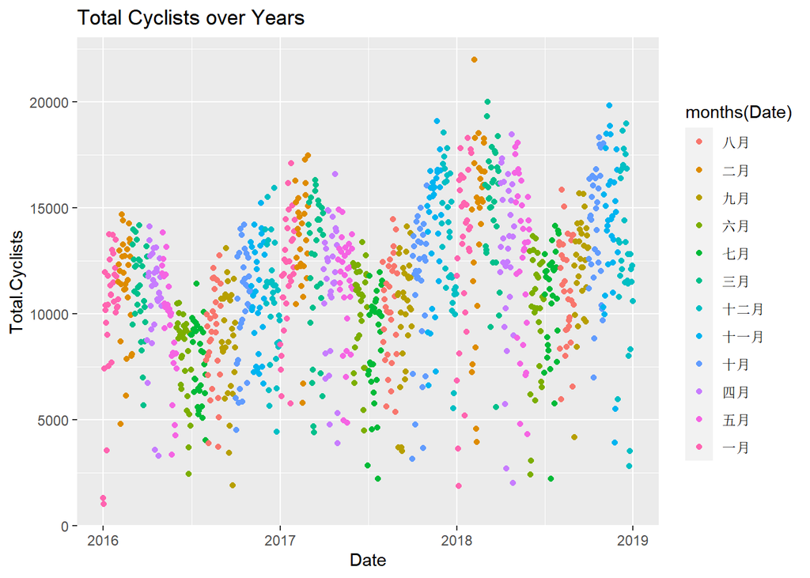

```r
ggplot(cycling_rainfall, mapping = aes(x = Date, y = Total.Cyclists)) +
  geom_point(mapping = aes(color = months(Date))) +
  ggtitle("Total Cyclists over Years")
```

We can roughly see that cyclists have a wave pattern through years. In June, July and August, there are less cyclists maybe because it’s winter in NZ. Oppositely, in January, February and March, more cyclists choose to ride their bike in summer.

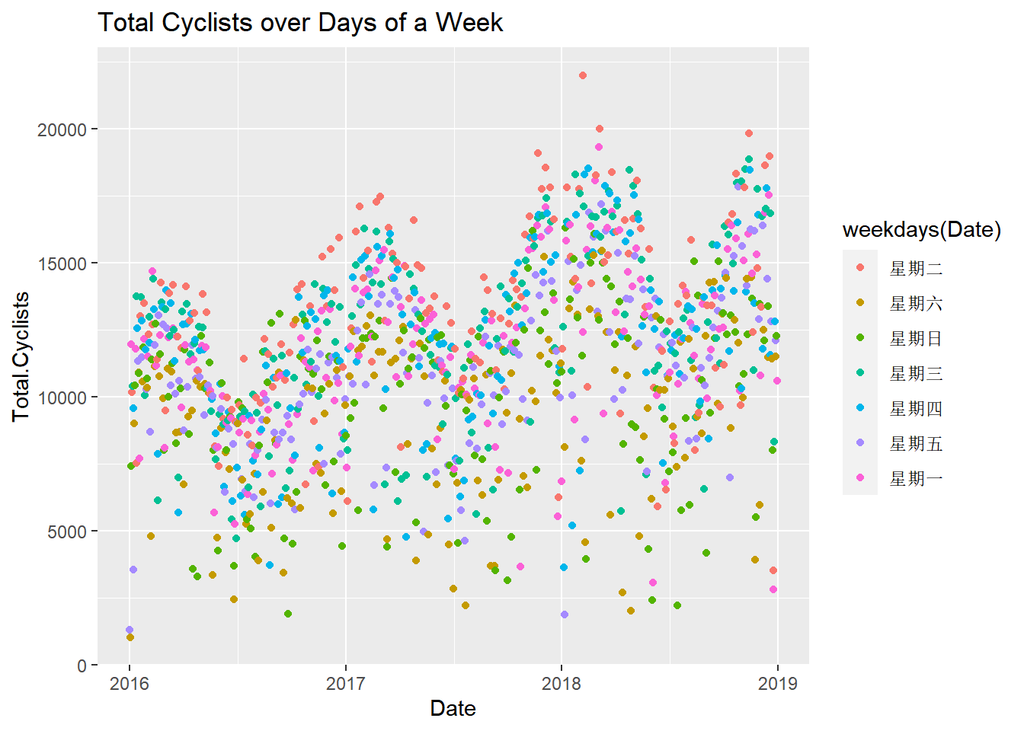

```r
ggplot(cycling_rainfall, mapping = aes(x = Date, y = Total.Cyclists)) +
  geom_point(mapping = aes(color = weekdays(Date))) +
  ggtitle("Total Cyclists over Days of a Week")
```

Since it tells little story about how the cyclists change over days of a week. Let’s try draw a box plot.

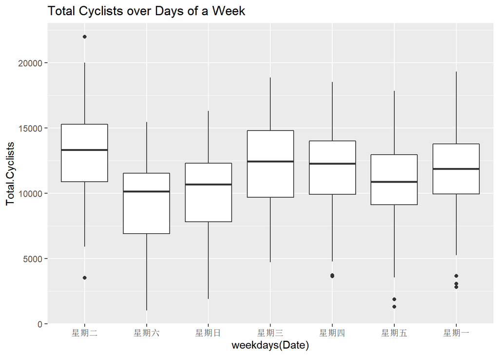

```r
ggplot(cycling_rainfall, mapping = aes(x = weekdays(Date), y = Total.Cyclists)) +
  geom_boxplot() +
  ggtitle("Total Cyclists over Days of a Week")
```

We can see that on Tuesday and Wednesday more people choose to ride bikes. But on Saturday and Sunday, there are less cyclists, maybe people just want to stay at home or take their private cars.

Now, let’s analyze the trend of cyclists with rainfall.

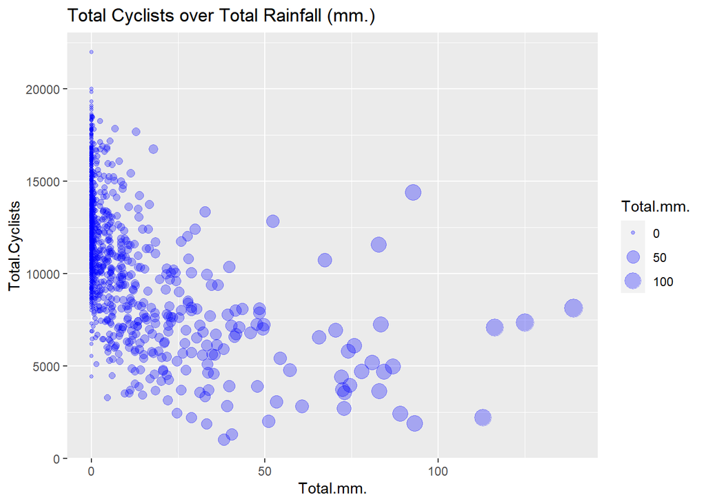

```r
ggplot(cycling_rainfall, mapping = aes(x = Total.mm., y = Total.Cyclists)) +
  geom_point(mapping = aes(size = Total.mm.), color = "blue", alpha = 0.3) +
  ggtitle("Total Cyclists over Total Rainfall (mm.)")
```

From the picture, we can see that cyclists have a negative trend with rainfall. It’s reasonable because people would like to take other transportation in rainy days.

Maybe we also interested in rainfall over time.

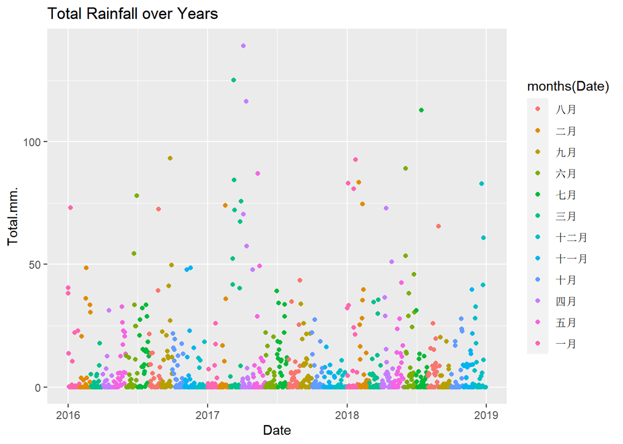

```r
ggplot(cycling_rainfall, mapping = aes(x = Date, y = Total.mm.)) +
  geom_point(mapping = aes(color = months(Date))) +
  ggtitle("Total Rainfall over Years")
```

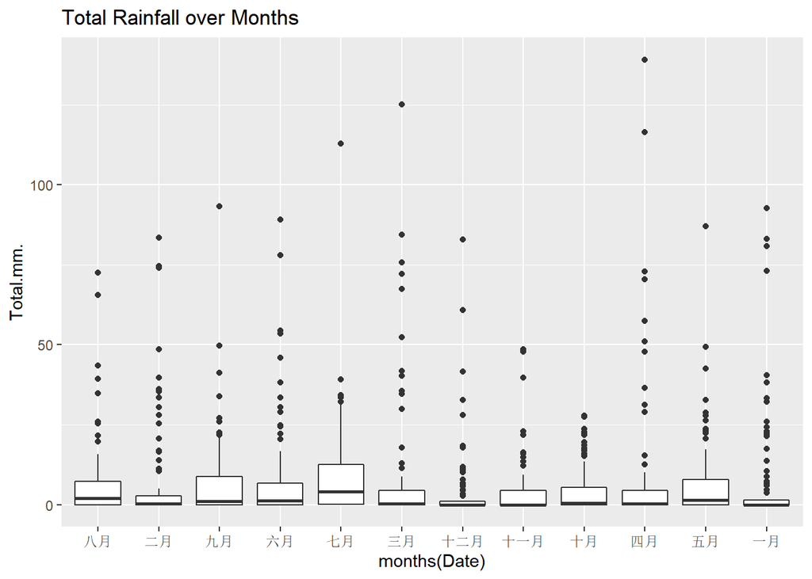

```r
ggplot(cycling_rainfall, mapping = aes(x = months(Date), y = Total.mm.)) +
  geom_boxplot() +
  ggtitle("Total Rainfall over Months")
```

In June, July, August and September, it seems have more rainy days than in December, January and February.

## 4. Question 4

Initially, we decide to fit model to predict the amount of cyclists.

According to the `marking_guide.xlsx`, we need to extract season factor from `Date`. Since the package `season` is failed on my R, we use a function instead the package.

```r
# https://stackoverflow.com/questions/9500114/find-which-season-a-particular-date-belongs-to

season <- function(DATES) {
    WS <- as.Date("2012-12-15", format = "%Y-%m-%d") # Winter Solstice
    SE <- as.Date("2012-3-15",  format = "%Y-%m-%d") # Spring Equinox
    SS <- as.Date("2012-6-15",  format = "%Y-%m-%d") # Summer Solstice
    FE <- as.Date("2012-9-15",  format = "%Y-%m-%d") # Fall Equinox

    # Convert dates from any year to 2012 dates
    d <- as.Date(strftime(DATES, format="2012-%m-%d"))

    ifelse (d >= WS | d < SE, "Winter",
      ifelse (d >= SE & d < SS, "Spring",
        ifelse (d >= SS & d < FE, "Summer", "Fall")))
}
```

```r
model_with_season <-  lm(Total.Cyclists~year(Date) + season(Date) + day(Date) + Total.mm., data = cycling_rainfall)
coef(summary(model_with_season))
```

```
##                         Estimate   Std. Error      t value      Pr(>|t|)
## (Intercept)        -3.098262e+06 1.864174e+05 -16.62002185  1.869371e-55
## year(Date)          1.542463e+03 9.242353e+01  16.68907244  7.451071e-56
## season(Date)Spring -6.230223e+02 2.134686e+02  -2.91856690  3.588749e-03
## season(Date)Summer -2.459386e+03 2.134066e+02 -11.52441069  4.464667e-29
## season(Date)Winter  1.232343e+02 2.144287e+02   0.57470970  5.656063e-01
## day(Date)          -7.398807e-01 8.568046e+00  -0.08635349  9.312013e-01
## Total.mm.          -1.151747e+02 4.847762e+00 -23.75832470 7.286926e-101
```

Let’s just use `month` instead of `season` and see how it works.

```r
model_with_month <-  lm(Total.Cyclists~year(Date) + month(Date) + day(Date) + Total.mm., data = cycling_rainfall)
coef(summary(model_with_month))
```

```
##                  Estimate   Std. Error     t value     Pr(>|t|)
## (Intercept) -3.102097e+06 2.008039e+05 -15.4483925 7.732065e-49
## year(Date)   1.544246e+03 9.955679e+01  15.5112017 3.472588e-49
## month(Date) -7.244220e+01 2.362804e+01  -3.0659416 2.223236e-03
## day(Date)   -1.590369e+00 9.228988e+00  -0.1723233 8.632153e-01
## Total.mm.   -1.181187e+02 5.225813e+00 -22.6029256 4.326859e-93
```

It also works in a reasonable degree, because `month` can be converted to `season` and vice versa.

In both models, `Total.mm.` has negative influence for cyclists, which is consistent to our pictures above. In rainy days, people would like to take other transportation instead of their bike.

## 5. Question 5

According to our coefficient summary, `Total.mm.` has considerable negative influence (-1.2e2) on `Total.Cyclists` with p-value 4.3e-93. It tells us that if the day has more rainfall, people will not choose to ride their bike. One mm. rainfall increasing will cause decreasing of at least 115 cyclists according to `model_with_season`.

Another interesting one is that `year(Date)` seems has a positive influence (1.5e3) on `Total.Cyclusts` with p-value 3.5e-49. It may tell us more people will choose to ride their bikes in future. About 1.5e3 people increase per year.